# A quick tour of **HDclust**

## Train an HMM-VB model with unknown variable block structure

If a variable block structure is unknown, one can search for it with **hmmvbTrain()** function. The search is performed by a greedy algorithm. Thus multiple permutations of variables are needed for the best estimation of the variable block structure. With many permutations, the search becomes a time-consuming process, and to accelerate it, we advice to use as many cores as your machine has. This is done with parameter **nthread**.

```r
data("sim2")
set.seed(12345)
hmmvb <- hmmvbTrain(sim2[1:5], searchControl=vbSearchControl(nperm=5), nthread=1)
show(hmmvb)
```

```
#> --------------------------------------
#> Hidden Markov Model on Variable Blocks
#> --------------------------------------
#>
#> ------------------------
#> Variable block structure
#> ------------------------
#>
#> Data dimensionality = 5
#>
#> Number of variable blocks = 1
#>
#> Dimensionality of variable blocks: 5
#>
#> Number of states in variable blocks: 12
#>
#> Variable order in variable blocks:
#> Block 1 : 1 2 3 4 5
#> ------------------------
#>
#> BIC = 25014.09
#>
#> Covariance matrices are diagonal = FALSE
#>
#> To show parameters of HMMs, access elements in HmmChain list.
```

Suggested variable block structure has a single variable block. That is in hand with the data, which was generated from a mixture of 10 Gaussian components. After finding the variable block structure, we recommend to run model selection to refine the number of mixture components:

```r
modelBIC <- hmmvbBIC(sim2[1:5], VbStructure=getVb(hmmvb), numst=1:15, nthread=1)
```

```r
show(modelBIC)
```

```
#> ------------------------------------------------------
#> Optimal number of states: 11 with BIC: 24849.79
#> ------------------------------------------------------
```

## Clustering with HMM-VB

After training the HMM-VB model we can perform data clustering. If variable block structure is known, we can start with model selection to refine number of mixture components in variable blocks. The output object of type **HMMVBBIC** is then used in function **hmmvbClust()** with argument **bicObj** to perform clustering.

```r
data("faithful")
VbStructure <- vb(nb=1, dim=2, numst=1)
set.seed(12345)
modelBIC <- hmmvbBIC(faithful, VbStructure)
```

```r
clust <- hmmvbClust(faithful, bicObj=modelBIC)
show(clust)
```

```
#> ------------------------------------------------------
#> Clustering with Hidden Markov Model on Variable Blocks
#> ------------------------------------------------------
#>
#> Number of clusters = 2
#>
#> Cluster sizes: 97 175
```

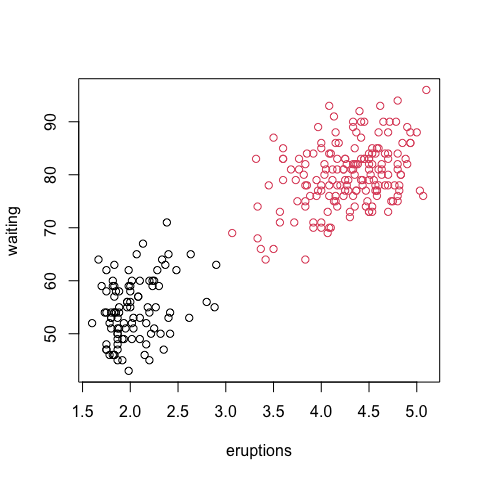

```r
plot(faithful[,1], faithful[,2], xlab='eruptions', ylab='waiting', col=getClsid(clust))
```

**hmmvbClust()** returns an object of type **HMMVBclust** that contains the clustering results, including Viterbi sequences and cluster modes.

```r
clustParam <- getClustParam(clust)
mode <- clustParam$mode # a matrix with cluster modes
vseq <- clustParam$vseq # A list with integer vectors representing distinct Viterbi sequences for the dataset
```

If variable block structure is unknown, we first search for it, then refine number of mixture components with model selection, and perform the clustering.

```r
# If variable block structure is unknown
data("sim2")
set.seed(12345)

# find variable block structure
hmmvb <- hmmvbTrain(sim2[,1:5], searchControl=vbSearchControl(nperm=5), nthread=1)

# refine number of states in variable block structure by model selection
modelBIC <- hmmvbBIC(sim2[,1:5], VbStructure=getVb(hmmvb), numst=1:15, nthread=1)
```

```r
clust <- hmmvbClust(data=sim2[,1:5], bicObj=modelBIC)
show(clust)
```

```
#> ------------------------------------------------------
#> Clustering with Hidden Markov Model on Variable Blocks
#> ------------------------------------------------------
#>
#> Number of clusters = 10
#>
#> Cluster sizes: 109 500 508 1136 504 753 502 485 49 454
```

Clustering results can also be plotted using two visualization algorithms.

By default results will be plotted using t-SNE algorithm from **Rtsne** package.

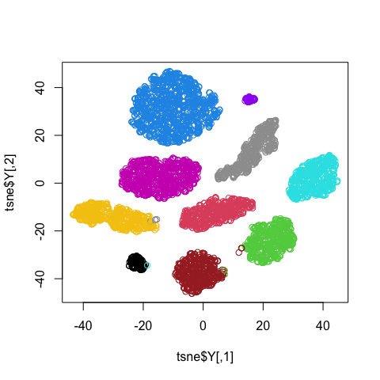

```r
palette(c(palette(), "purple", "brown")) # extend palette to show all 10 clusters
plot(clust)
```

Results can also be shown in 2 dimensional space reduced by PCA:

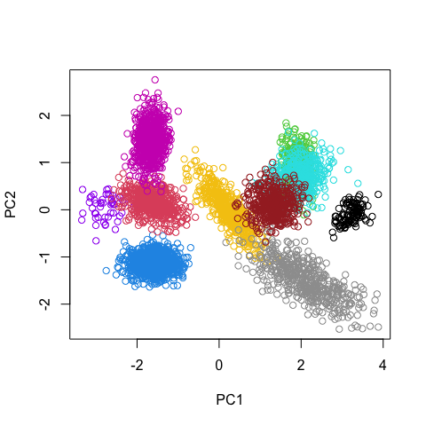

```r
plot(clust, method='PCA')
```

## Cluster alignment

Imagine that you have already performed clustering with HMM-VB for one data set and now another similar data set is available. One can use existing HMM-VB model and align cluster labels of the second data set with the clusters obtained for the first data set:

```r
data("sim3")

# split data set in two halves
X1 = sim3[1:500,]
X2 = sim3[501:1000,]

set.seed(12345)
Vb <- vb(2, 40, c(10,30), c(3,5), list(c(1:10),c(11:40)))

# train HMM-VB on dataset X1 and cluster data
hmmvb <- hmmvbTrain(X1[1:40], VbStructure=Vb)
clust1 <- hmmvbClust(X1[1:40], model=hmmvb)
show(clust1)
```

```
#> ------------------------------------------------------
#> Clustering with Hidden Markov Model on Variable Blocks
#> ------------------------------------------------------
#>
#> Number of clusters = 5
#>
#> Cluster sizes: 341 27 80 26 26
```

```r
# cluster data set X2 using HMM-VB and cluster parameters for dataset X1
clust2 <- hmmvbClust(X2[1:40], model=hmmvb, rfsClust=getClustParam(clust1))
```

```
#> All found viterbi sequences match with sequences in reference clusters
```

```r
show(clust2)
```

```
#> ------------------------------------------------------
#> Clustering with Hidden Markov Model on Variable Blocks
#> ------------------------------------------------------
#>
#> Number of clusters = 5
#>
#> Cluster sizes: 346 17 103 13 21
```

If you also want to compute the loglikelihood for the new data set, it can be realized by setting the parameter getlikelh to be TRUE in **clustControl()**:

```r
clust2 <- hmmvbClust(X2[1:40], model=hmmvb, rfsClust=getClustParam(clust1), control=clustControl(getlikelh = TRUE))
```

```
#> All found viterbi sequences match with sequences in reference clusters
```

```r
# we just illustrate the loglikelihood of the first 10 data points beacause the data set is huge
getLoglikehd(clust2)[1:10]
```

```
#>  [1]   17.653071    9.835956   16.587321 -476.377336   22.434999   20.201192
#>  [7]   19.094334   13.725819    7.412597    4.031532
```

## Solution for slow data clustering with many changes in mode merging parameters

If data clustering takes a significant amount of time and many changes in mode merging parameters are required to achieve the desired clustering result, we recommend to use **hmmvbFindModes()** and **clustModes()**. Function **hmmvbFindModes()** finds all density modes in the data, and **clustModes()** clusters the modes using hierarchical clustering. Under the hood **clustModes()** uses **dist()**, **hclust()** and **cutree()** calls from the package **stats**, and a user can specify parameters for all of them with **dist.args**, **hclust.args** and **cutree.args** arguments.

```r
data("sim3")

set.seed(12345)
Vb <- vb(2, 40, c(10,30), c(3,5), list(c(1:10),c(11:40)))

# train HMM-VB
hmmvb <- hmmvbTrain(sim3[1:40], VbStructure=Vb)

# find all density modes
modes <- hmmvbFindModes(sim3[1:40], model=hmmvb)
show(modes)
```

```
#> ------------------------------------------------------
#> Clustering with Hidden Markov Model on Variable Blocks
#> ------------------------------------------------------
#>
#> Number of clusters = 5
#>
#> Cluster sizes: 682 83 183 46 6
```

```r
# cluster density modes
mergedModes <- clustModes(modes, cutree.args = list(h=1.0))

show(mergedModes)
```

```
#> ------------------------------------------------------
#> Clustering with Hidden Markov Model on Variable Blocks
#> ------------------------------------------------------
#>
#> Number of clusters = 5
#>
#> Cluster sizes: 682 83 183 46 6
```

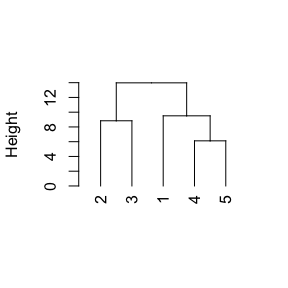

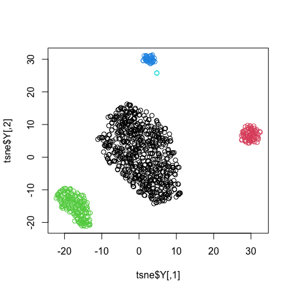

```r
plot(mergedModes)
```

# References

Lin Lin and Jia Li, “Clustering with hidden Markov model on variable blocks,” **Journal of Machine Learning Research**, 18(110):1-49, 2017.